# The Changing Cyber Threat Landscape in Kenya

Phase 2: Data collection, cleaning and exploratory analysis  
Data Forge · CMT 429 Introduction to Data Science · CUEA

Sophie Muthoni Muchiri (1060697)

Consolata Makau (1064147)

Nathan Ochieng’ Otieno (1061016)

Quintone Mark Juma (1061327)

Felix Kiptoo Kerich (1060821)

Bradley Mudhune (1060674)

30th October 2026

## Our four questions

1. **Kenya trends:** how have detected cyber threats in Kenya changed from quarter to quarter?
2. **What gets exploited:** which vulnerabilities do attackers actually use?
3. **What to fix first:** can we rank vulnerabilities better than the usual severity score?
4. **Phishing:** does a phishing detector trained on global data work on Kenyan websites?

# How we collected the data

## Six sources, all public, all logged

| Source | What it gives us | Size | Collected by script |
| --- | --- | --- | --- |
| KE-CIRT/CC quarterly reports (Communications Authority) | Detected threat events in Kenya, by category | 26 PDF reports, 2020 to 2026 | download_ca_reports.R |
| NVD (National Vulnerability Database) | Every published vulnerability (CVE) and its severity | 315,909 CVEs | 02_download_nvd.R |
| CISA KEV (Known Exploited Vulnerabilities) | CVEs confirmed as exploited in real attacks | 1,758 CVEs | 01_download_kev.R |
| EPSS (Exploit Prediction Scoring System) | Daily predicted chance each CVE gets exploited | 271,765 scores (1 Jan 2025) | 06_download_epss.R |
| PhiUSIIL (UCI) | Labelled phishing and legitimate URLs | 235,795 URLs | UCI download |
| Kenyan URL list (built by us) | Real legitimate Kenyan websites | 308 URLs, 119 organisations | collect_kenya_urls.R |

Every download is recorded in `docs/source_log.csv` (41 rows): link, date, who downloaded it, terms of use.

## Collection problems we solved

**Kenya reports**

- Some reports were no longer on the live site, so we used **Wayback Machine** archived copies
- Jul–Dec 2021 figures were inside **Sector Statistics** reports, not the cyber reports
- One PDF arrived broken and was downloaded again
- Files renamed by quarter: `CA_cyber_2021-07.pdf`

**Global data**

- NVD’s API is slow and rate-limited, so we used the **yearly JSON files** (fkie-cad mirror)
- EPSS files start with a comment line, so they are read with `skip = 1`
- Kenyan URLs were collected **in batches by sector** and checked by hand: 0 duplicates, 100% https

# How we cleaned and transformed it

## Raw files are never edited: scripts do every step

**`data/raw/`**

As downloaded

- CA report PDFs
- NVD yearly JSON
- KEV CSV
- EPSS CSV
- PhiUSIIL CSV
- Kenyan URLs

**`scripts/` + `R/`**

What changes it

- `03_build_nvd.R`: nested JSON to one row per CVE
- `04_build_vulns.R`: join NVD + KEV + EPSS
- `05_build_phishing.R`: labels
- `06_build_url_features.R`: URL-only features

**`data/processed/`**

What analysis reads

- `vulns.rds`: 315,909 rows, 32 columns
- `phishing.rds`
- `phishing_url_features.rds`
- CA double-entry sheets

Judgement calls are written down in `docs/decisions.md`; data problems in `docs/data_quality.md`.

## What we added to the vulnerability table

```r
vulns <- readRDS("data/processed/vulns.rds")
vulns |> select(cve_id, cvss_score, severity, exploited, epss_2025_01_01,
                cwe_group, vendor_group, says_rce) |> glimpse()
```

| cve_id | cvss_score | severity | exploited | epss_2025_01_01 | vendor_group | says_rce |
| --- | --- | --- | --- | --- | --- | --- |
| CVE-2023-43378 | 6.1 | MEDIUM | FALSE | NA | Other | FALSE |
| CVE-2026-50766 | 5.4 | MEDIUM | FALSE | NA | Other | FALSE |
| CVE-2018-5057 | 8.8 | HIGH | FALSE | 0.0121 | adobe | FALSE |
| CVE-2024-5238 | 6.5 | MEDIUM | FALSE | 0.0004 | Other | FALSE |
| CVE-2024-43863 | 5.5 | MEDIUM | FALSE | 0.0004 | linux | FALSE |

- **exploited**: TRUE if the CVE is in KEV (1,554 of 315,909)
- **vendor_group / cwe_group**: rare vendors and weakness types grouped into “Other” so models can use them
- **says_rce / says_auth_bypass / says_sqli**: flags from the description text

## Kenya data: typed in twice, then checked by code

8 / 8

quarters where the categories add up exactly to the report’s total

0

differences between the two typists across 2 quarters compared so far

**Why two people?**

The numbers are inside PDFs, so they must be typed by hand. Two people enter each quarter separately; code compares the two sheets cell by cell.

**Why the totals check?**

If one category is mistyped, the categories no longer add up to the report’s own total.

## A data-quality finding: who scores vulnerabilities has changed

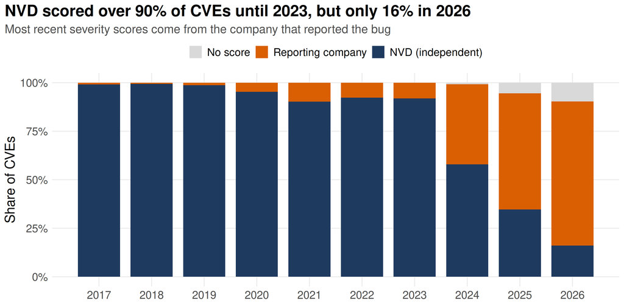

# What the data shows: Kenya

## Detected threat events in Kenya have grown enormously

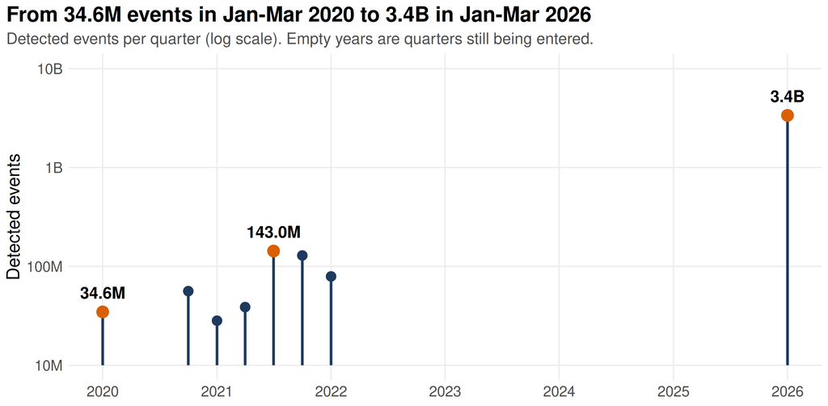

These are **detected** events (mostly blocked scans and attempts), not confirmed breaches.

## What kind of threats: malware’s share is shrinking

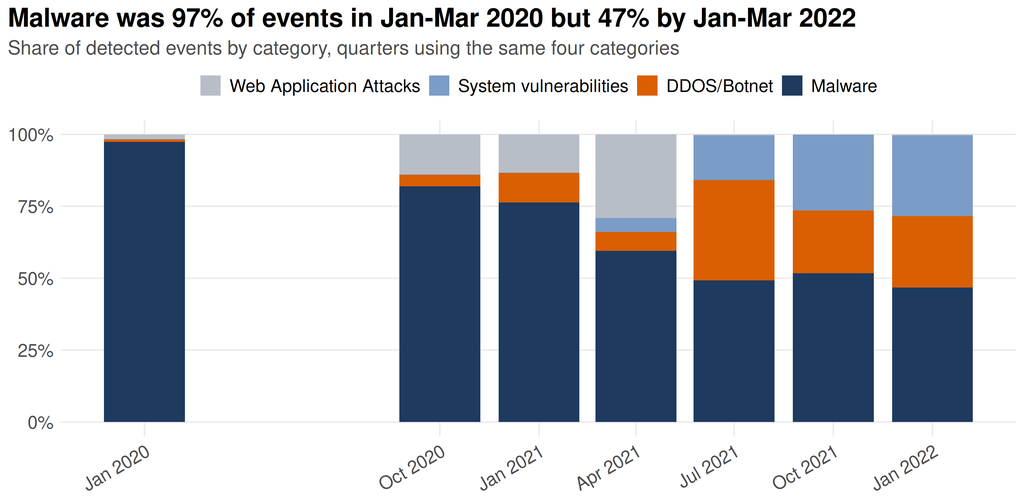

By Jan-Mar 2026 the reports use 6 categories, and “System Attacks” alone is 96% of events. Category names change between reports, so we are building a category map before comparing them directly.

# What the data shows: vulnerabilities

## More vulnerabilities are published every year

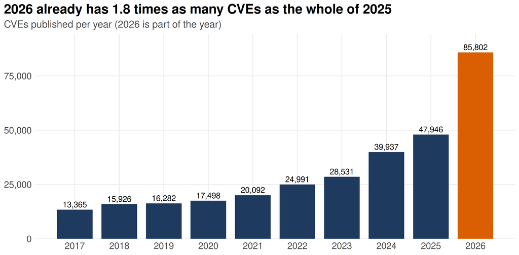

## Very few vulnerabilities are ever exploited

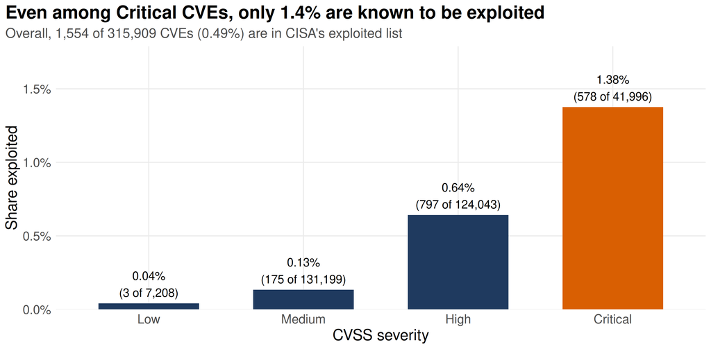

## Clues in the description text

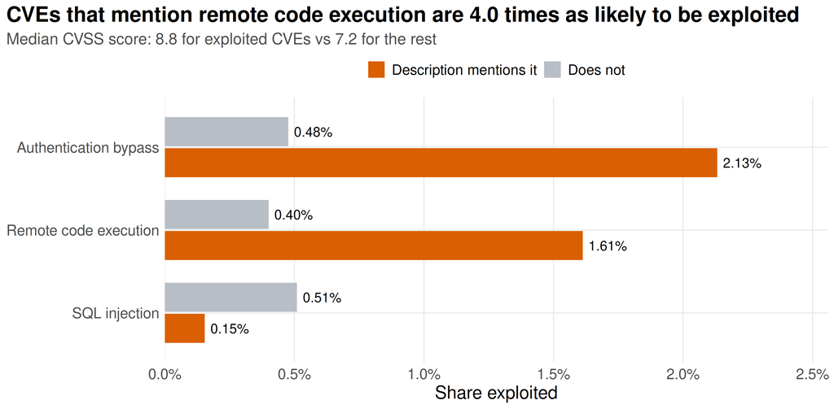

## A few vendors dominate the exploited list

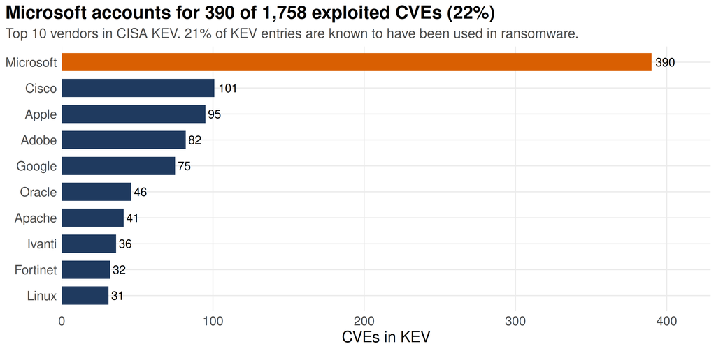

## Preview: which list finds exploited CVEs faster?

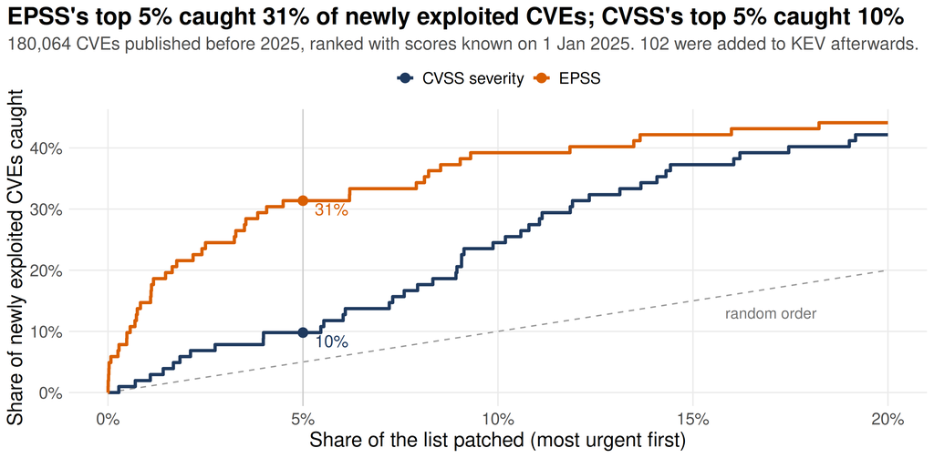

# What the data shows: phishing

## Some features are too good to be true

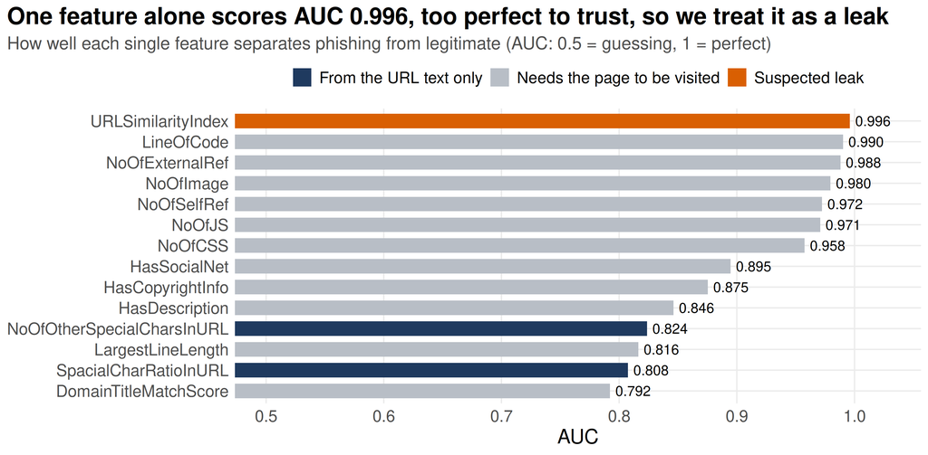

## The training data has never seen a Kenyan login page

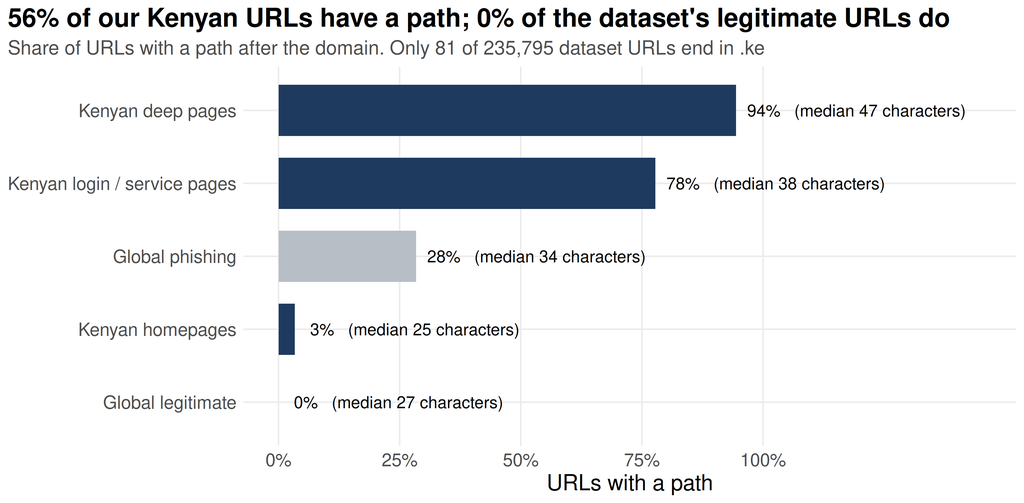

# Wrapping up

## What we found in Phase 2

- **Kenya:** detected events grew from 34.6M a quarter to 3.4B, and the threat mix moved away from malware
- **Exploitation is rare:** 0.49% of CVEs, and only 1.4% of Critical ones
- **Severity is a weak guide:** EPSS caught about 3× more newly exploited CVEs in the top 5%
- **Data quality:** most new severity scores no longer come from an independent reviewer
- **Phishing:** the global dataset has a leak and has never seen Kenyan login pages

## Limitations and next steps

**Honest limitations**

- CA figures are **detected events**, not breaches
- Some Kenya quarters are **still being entered** and double-checked
- Category names change between reports
- KEV is US-focused: **known** exploitation only
- PhiUSIIL is global; our Kenyan list is legitimate pages only

**Next phase**

- Finish double entry and the **category map**
- Kenya trend analysis (Part 1)
- Build our own **prioritisation model** and test it against CVSS and EPSS (Part 3)
- Test a URL-only phishing model on **Kenyan sites** (Part 4)

All code and data: github.com/Sophie-Muchiri12/data-forge-cyber. Every number on these slides is computed in R from the repo files.

## Questions?

Data Forge